# IE 360 Project Report

Group 19: İlker Zeybek 2014402147

6 July 2020

```r
library(png)
library(grid)
```

## INTRODUCTION

E-commerce (electronic commerce) is the activity of electronically buying or selling of products on online services or over the Internet. Electronic commerce draws on technologies such as mobile commerce, electronic funds transfer, supply chain management, Internet marketing, online transaction processing, electronic data interchange (EDI), inventory management systems, and automated data collection systems.(1)

In this project, we are, as a class, working with one of the highest rated e-commerce companies, namely Trendyol. Trendyol gathers the user generated data about it’s products as it is stated above in the definition of e-commerce. The products are selected from various categories and brands. Here is the eight selected products:

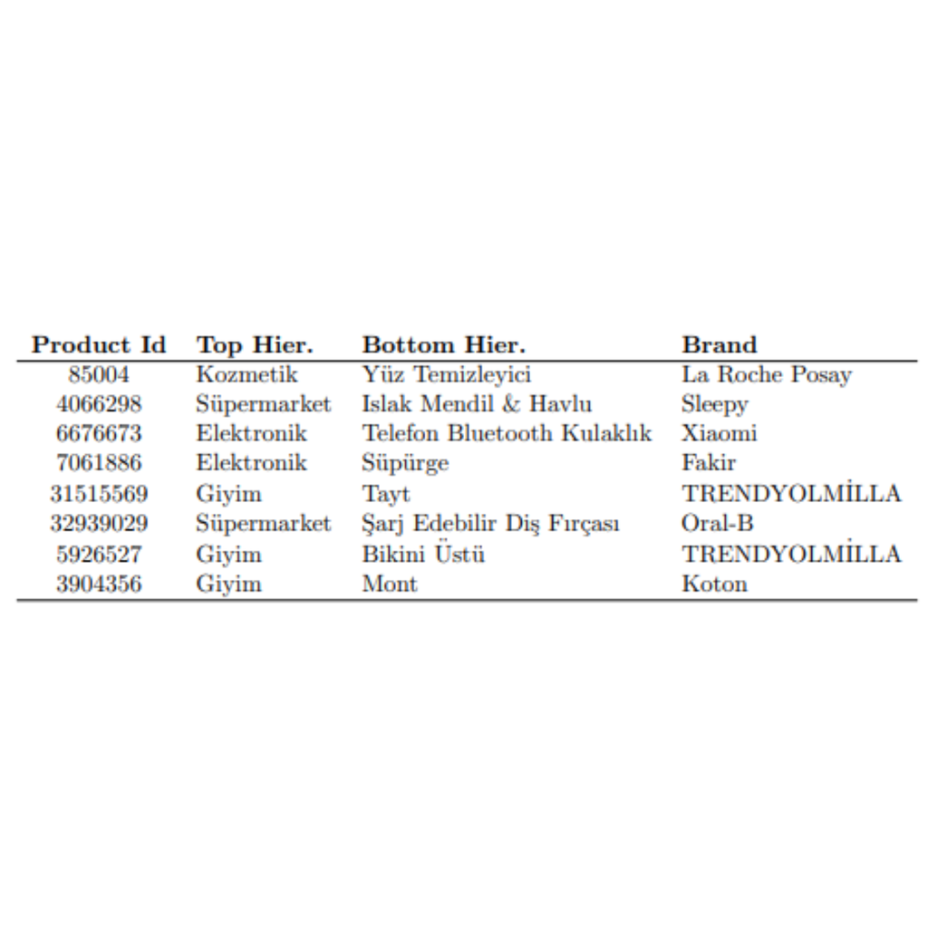

```r
img1 <- readPNG('C:/Users/ilker zeybek/Desktop/products.png')
grid::grid.raster(img1)
```

The project is organized as a live competition, where students are expected to provide a prediction of sales per product each day. For the ease of submission, an API has been built by the staff of IE 360, to submit predictions each day. The aim of the project is to make future forecasts of eight different product sales. Accurate forecasts can help reducing the wastes by the company and it can increase the profits made from these products.

Groups are expected to submit their predictions through the provided scripts (python and r) or through the site. Groups have to provide their forecasts regularly before 13:00 every day, multiple submissions are accepted. For the daily ranking, weighted mean absolute percentage error (WMAPE) is used. Formula of the WMAPE is the following:

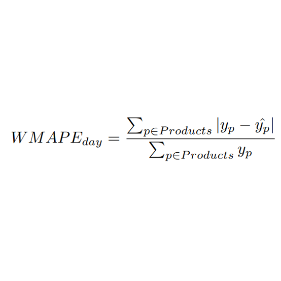

```r
img2 <- readPNG('C:/Users/ilker zeybek/Desktop/wmape.png')
grid::grid.raster(img2)
```

Groups are free to choose their models for prediction. As an individual, I have tried various methods to predict next day’s sales. I have tried Simple Exponential Model, Holt’s Model, Forecasts with Different Lag Values, Linear Regression Model with Lags, and most importantly I have implemented the ARIMA model.

## RELATED LITERATURE

During the COVID-19 pandemic, we had to do our classes with an online meeting. During this time, we are assigned with several online courses about forecasting and time series by our instructor. The site that we taken our online courses is Datacamp, and there are many online classes about Data Science, Machine Learning, Data Manipulation, etc. We have taken the following courses:

1. Manipulating Time Series Data with xts and zoo in R, by Jeffrey Ryan, creator of xts and quantmod.
2. Time Series Analysis in R, by David S. Matteson, Associate Professor at Cornell University.
3. Forecasting in R, by Rob J. Hyndman, Professor of Statistics at Monash University.
4. Data Manipulation with data.table in R, by Matt Dowle, author of data.table.
5. Forecasting Product Demand in R, by Aric LaBarr, Director and Senior Scientist at Elder Research.

These courses are very useful for manipulating, cleaning, and building forecast models for the data provided by Trendyol. After these courses, I have researched further about forecasting models that I mentioned in the Introduction part, and I have gained more insight about their statistical math background. The online textbook that helped me to develop more interest in the forecasting is “Forecasting: Principles and Practice” which can be accessed from https://otexts.com/fpp2/ site. The textbook has applied R code that helps visualizing the concepts better. Lastly, third and most important source of information was the lectures that given by instructor Mustafa Gökçe Baydoğan.

## APPROACH

I have used several methods to forecast daily sales of the products. These methods are:

### Naive Forecast

Naive forecast is the simplest version of forecasting. It is an estimating technique in which the last period’s actuals are used as this period’s forecast, without adjusting or manipulating them. It is mostly used as comparison tool for another forecasting methods.

For naive forecasts, I have simply set all forecasts to be the value of the last observation. That is:

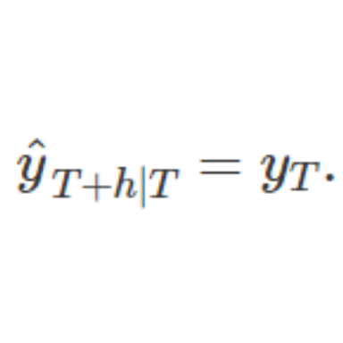

```r
img3 <- readPNG('C:/Users/ilker zeybek/Desktop/naive.png')
grid::grid.raster(img3)
```

### Simple Exponential Smoothing

Exponential smoothing is a rule of thumb technique for smoothing time series data using the exponential window function. Whereas in the simple moving average the past observations are weighted equally, exponential functions are used to assign exponentially decreasing weights over time. It is an easily learned and easily applied procedure for making predictions. Exponential smoothing is often used for analysis of time-series data.(2)

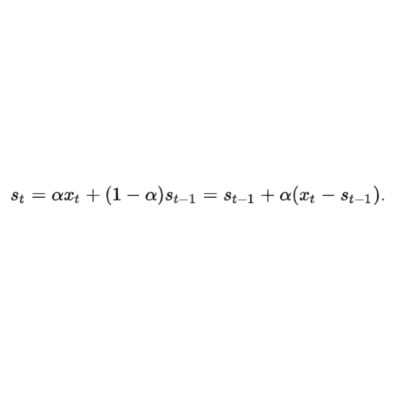

```r
img4 <- readPNG('C:/Users/ilker zeybek/Desktop/ses.png')
grid::grid.raster(img4)
```

### Holt’s Model

Holt’s two-parameter model, also known as linear exponential smoothing, is a popular smoothing model for forecasting data with trend. Holt’s model has three separate equations that work together to generate a final forecast. The method is also called double exponential smoothing or trend-enhanced exponential smoothing.(3) Since the data of the all products does not include an obvious trend, this model did not worked well too.

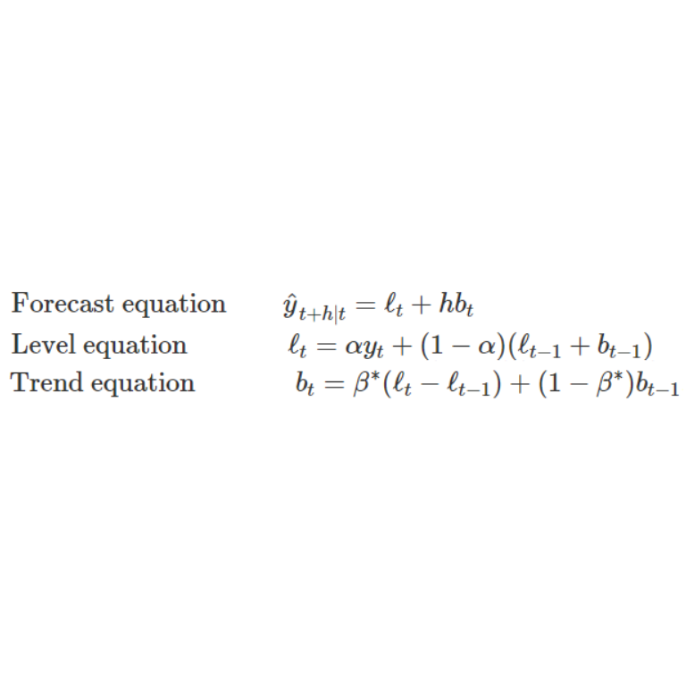

```r
img5 <- readPNG('C:/Users/ilker zeybek/Desktop/holt.png')
grid::grid.raster(img5)
```

### Forecasts with Lags

This method is as simple as naive forecasting. It is basically a naive forecast, but it only considers the data of n days before, where n is the lag value. The reason that I have used this method is because it is taught in the lectures of Mustafa Gökçe Baydoğan for demonstration purposes. This type of forecasting may be useful if there is obvious n-day seasonality in the data.

### Linear Regression with Lagged Values

Linear regression is a linear approach to modeling the relationship between a scalar response (or dependent variable) and one or more explanatory variables (or independent variables). Since we use the linear regression with 2 days and 7 days lagged values, it can be considered as autoregressive model. This method is also taught by the instructor Mustafa Gökçe Baydoğan, in his online lectures of IE 360 Time Series Analysis.

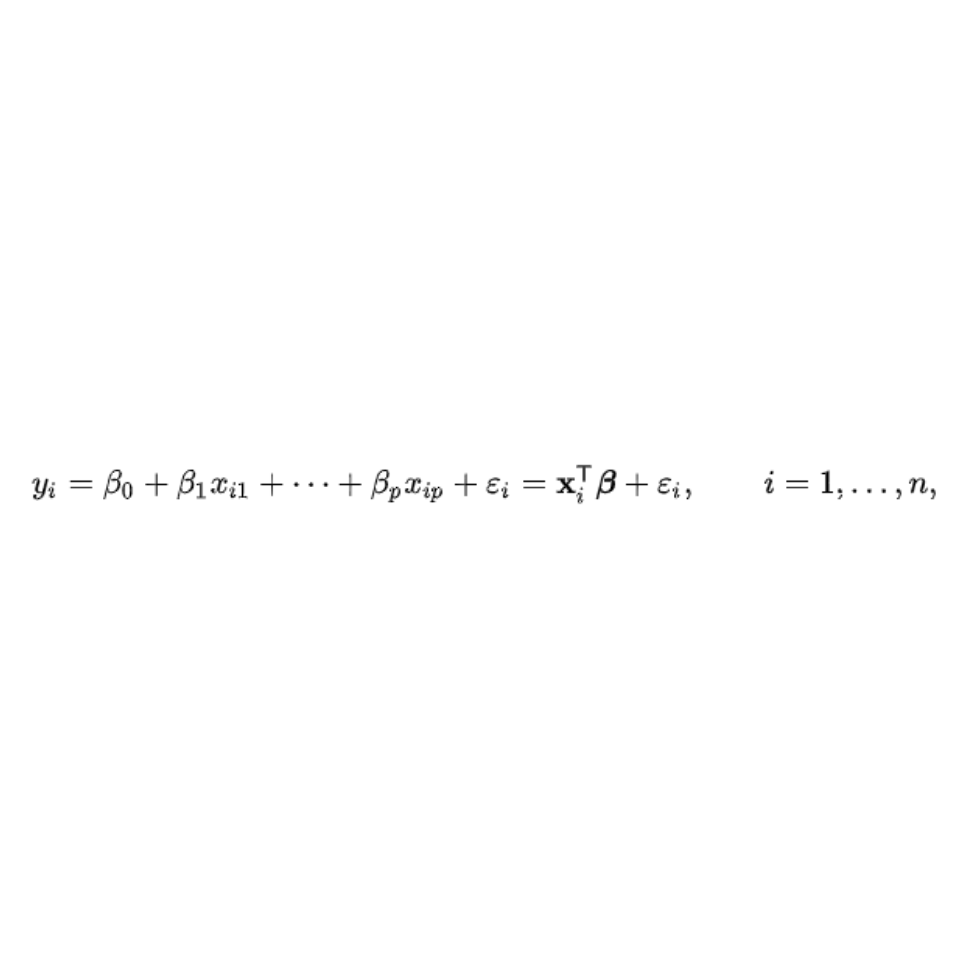

```r
img6 <- readPNG('C:/Users/ilker zeybek/Desktop/linear.png')
grid::grid.raster(img6)
```

### ARIMA

In a multiple regression model, we forecast the variable of interest using a linear combination of predictors. In an autoregression model, we forecast the variable of interest using a linear combination of past values of the variable. The term autoregression indicates that it is a regression of the variable against itself.

Thus, an autoregressive model of order p can be written as:

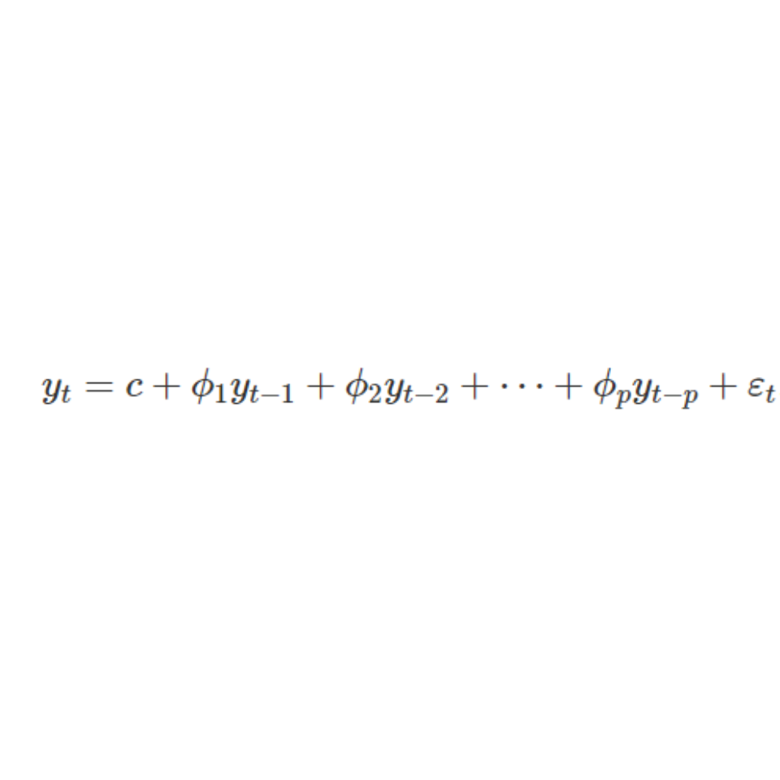

```r
img7 <- readPNG('C:/Users/ilker zeybek/Desktop/ar.png')
grid::grid.raster(img7)
```

Rather than using past values of the forecast variable in a regression, a moving average model uses past forecast errors in a regression-like model.

Thus, a moving average model of order q can be written as:

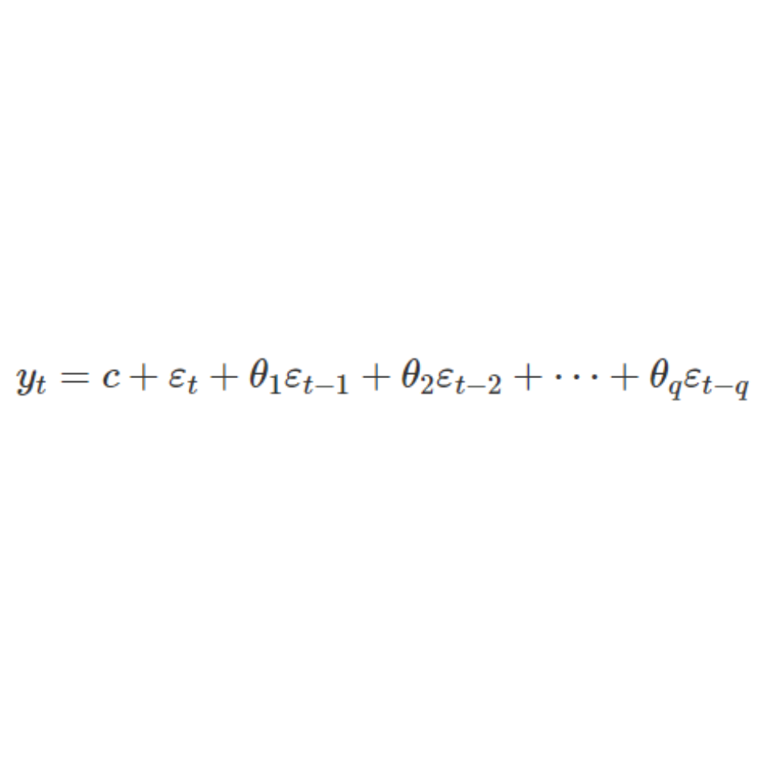

```r
img8 <- readPNG('C:/Users/ilker zeybek/Desktop/ma.png')
grid::grid.raster(img8)
```

If we combine differencing with autoregression and a moving average model, we obtain a non-seasonal ARIMA model. ARIMA is an acronym for AutoRegressive Integrated Moving Average (in this context, “integration” is the reverse of differencing). The full model can be written as:

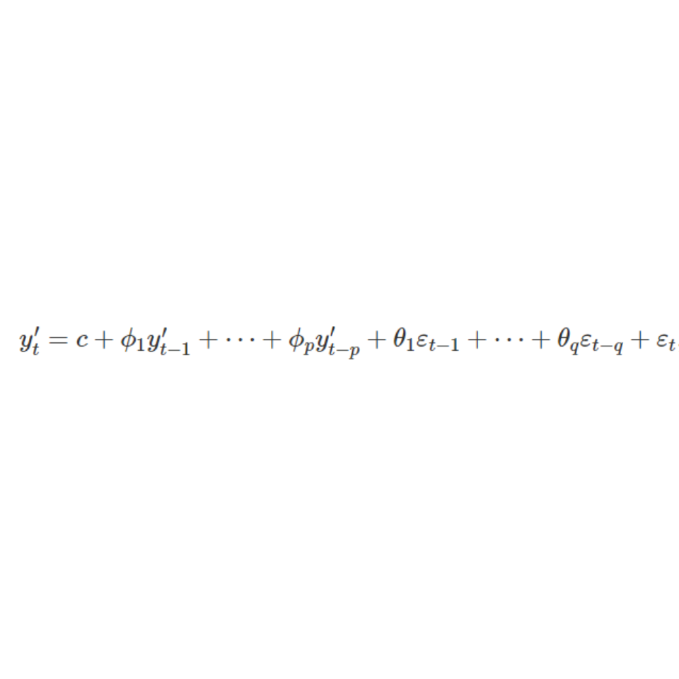

```r
img9 <- readPNG('C:/Users/ilker zeybek/Desktop/arima.png')
grid::grid.raster(img9)
```

For the future works, we have to approach this problem like a competitive company approaches. There are many popular methods and tools that we can use for predictions and building models. Machine Learning is currently leader in this field. Any prediction based work can be easily handled with machine learning algorithms. In the current business environment, engineers must adapt to the technological changes and they have to develop themselves with the current “data revolution”, or as Datacamp says in it’s advertisements, if we can not adapt the changes in the fast-paced evolving world, we will be “swept underneath”.

## CODE

```r
library(readr)
library(ggplot2)
library(forecast)
library(fpp2)
library(TTR)
library(dplyr)
library(caTools)
library(lubridate)
library(TSstudio)
getwd()
setwd("C:/Users/ilker zeybek/Desktop/360 proje")
mape <- function(actual,pred){
  mape <- mean(abs((actual - pred)/actual))*100
  return (mape)
}
data32939029 = read.csv("32939029.csv")
glimpse(data32939029)
set.seed(360)
ts32939029 <- ts(data32939029[, 5], start = c(2019, 11, 23), end = c(2020, 06, 12), frequency = 365)
split_data <- ts_split(ts32939029, sample.out = 75)
training32939029 <- split_data$train
test32939029 <- split_data$test
nrow(train32939029)
nrow(test32939029)
ts32939029 <- ts(train32939029[, 5], start = c(2019, 11, 23), end = c(2020, 06, 12), frequency = 365)
se_model <- ses(ts32939029, h = 1)
summary(se_model)
df_fc = as.data.frame(se_model)
test32939029$simplexp = df_fc$`Point Forecast`
mape(test32939029$sold_count, test32939029$simplexp)
holt_model <- holt(ts32939029, h = 1)
summary(holt_model)
df_holt = as.data.frame(holt_model)
test32939029$holt = df_holt$`Point Forecast`
mape(test32939029$sold_count, test32939029$holt)

set.seed(360)
data31515569 = read.csv("31515569.csv")
ts331515569 <- ts(data31515569[, 5], start = c(2019, 09, 22), end = c(2020, 06, 12), frequency = 365)
split_data <- ts_split(ts31515569, sample.out = 75)
training31515569 <- split_data$train
test31515569 <- split_data$test
nrow(train31515569)
nrow(test31515569)
ts31515569 <- ts(train31515569[, 5], start = c(2019, 09, 22), end = c(2020, 06, 12), frequency = 365)
se_model2 <- ses(ts31515569, h = 1)
summary(se_model2)
df_fc2 = as.data.frame(se_model2)
test31515569$simplexp = df_fc2$`Point Forecast`
mape(test31515569$sold_count, test31515569$simplexp)
holt_model2 <- holt(ts31515569, h = 1)
summary(holt_model2)
df_holt2 = as.data.frame(holt_model2)
test31515569$holt2 = df_holt2$`Point Forecast`
mape(test31515569$sold_count, test31515569$holt)

set.seed(360)
data7061886 = read.csv("7061886.csv")
ts7061886 <- ts(data7061886[, 5], start = c(2019, 07, 27), end = c(2020, 06, 12), frequency = 365)
split_data <- ts_split(ts7061886, sample.out = 75)
training7061886 <- split_data$train
test7061886 <- split_data$test
nrow(train7061886)
nrow(test7061886)
ts7061886 <- ts(train7061886[, 5], start = c(2019, 07, 27), end = c(2020, 06, 12), frequency = 365)
se_model3 <- ses(ts7061886, h = 1)
summary(se_model3)
df_fc3 = as.data.frame(se_model3)
test7061886$simplexp = df_fc3$`Point Forecast`
mape(test7061886$sold_count, test7061886$simplexp)
holt_model3 <- holt(ts7061886, h = 1)
summary(holt_model3)
df_holt3 = as.data.frame(holt_model3)
test7061886$holt3 = df_holt3$`Point Forecast`
mape(test7061886$sold_count, test7061886$holt)

set.seed(360)
data6676673 = read.csv("6676673.csv")
ts6676673 <- ts(data6676673[, 5], start = c(2019, 06, 20), end = c(2020, 06, 12), frequency = 365)
split_data <- ts_split(ts6676673, sample.out = 75)
training6676673 <- split_data$train
test6676673 <- split_data$test
nrow(train6676673)
nrow(test6676673)
ts6676673 <- ts(train6676673[, 5], start = c(2019, 06, 20), end = c(2020, 06, 12), frequency = 365)
se_model4 <- ses(ts6676673, h = 1)
summary(se_model4)
df_fc4 = as.data.frame(se_model4)
test6676673$simplexp = df_fc4$`Point Forecast`
mape(test6676673$sold_count, test6676673$simplexp)
holt_model4 <- holt(ts6676673, h = 1)
summary(holt_model4)
df_holt4 = as.data.frame(holt_model4)
test6676673$holt4 = df_holt4$`Point Forecast`
mape(test6676673$sold_count, test6676673$holt)

set.seed(360)
data5926527 = read.csv("5926527.csv")
ts5926527 <- ts(data5926527[, 5], start = c(2019, 05, 19), end = c(2020, 06, 12), frequency = 365)
split_data <- ts_split(ts5926527, sample.out = 75)
training5926527 <- split_data$train
test5926527 <- split_data$test
nrow(train5926527)
nrow(test5926527)
ts5926527 <- ts(train5926527[, 5], start = c(2019, 05, 19), end = c(2020, 06, 12), frequency = 365)
se_model5 <- ses(ts5926527, h = 1)
summary(se_model5)
df_fc5 = as.data.frame(se_model5)
test5926527$simplexp = df_fc5$`Point Forecast`
mape(test5926527$sold_count, test5926527$simplexp)
holt_model5 <- holt(ts5926527, h = 1)
summary(holt_model5)
df_holt5 = as.data.frame(holt_model5)
test5926527$holt5 = df_holt5$`Point Forecast`
mape(test5926527$sold_count, test5926527$holt)

set.seed(360)
data4066298 = read.csv("4066298.csv")
ts4066298 <- ts(data4066298[, 5], start = c(2019, 09, 09), end = c(2020, 06, 12), frequency = 365)
split_data <- ts_split(ts4066298, sample.out = 75)
training4066298 <- split_data$train
test4066298 <- split_data$test
nrow(train4066298)
nrow(test4066298)
ts4066298 <- ts(train4066298[, 5], start = c(2019, 09, 09), end = c(2020, 06, 12), frequency = 365)
se_model6 <- ses(ts4066298, h = 1)
summary(se_model6)
df_fc6 = as.data.frame(se_model6)
test4066298$simplexp = df_fc6$`Point Forecast`
mape(test4066298$sold_count, test4066298$simplexp)
holt_model6 <- holt(ts4066298, h = 1)
summary(holt_model6)
df_holt6 = as.data.frame(holt_model6)
test4066298$holt6 = df_holt6$`Point Forecast`
mape(test4066298$sold_count, test4066298$holt)

set.seed(360)
data3904356 = read.csv("3904356.csv")
ts3904356  <- ts(data3904356 [, 5], start = c(2019, 05, 11), end = c(2020, 06, 12), frequency = 365)
split_data <- ts_split(ts3904356 , sample.out = 75)
training3904356  <- split_data$train
test3904356 <- split_data$test
nrow(train3904356)
nrow(test3904356)
ts3904356 <- ts(train3904356[, 5], start = c(2019, 05, 11), end = c(2020, 06, 12), frequency = 365)
se_model7 <- ses(ts3904356, h = 1)
summary(se_model7)
df_fc7 = as.data.frame(se_model7)
test3904356$simplexp = df_fc7$`Point Forecast`
mape(test3904356$sold_count, test3904356$simplexp)
holt_model7 <- holt(ts3904356, h = 1)
summary(holt_model7)
df_holt7 = as.data.frame(holt_model7)
test3904356$holt7 = df_holt7$`Point Forecast`
mape(test3904356$sold_count, test3904356$holt)

set.seed(360)
data85004 = read.csv("85004.csv")
ts85004  <- ts(data85004 [, 5], start = c(2019, 04, 30), end = c(2020, 06, 12), frequency = 365)
split_data <- ts_split(ts85004 , sample.out = 75)
training85004  <- split_data$train
test85004 <- split_data$test
nrow(train85004)
nrow(test85004)
ts85004 <- ts(train85004[, 5], start = c(2019, 04, 30), end = c(2020, 06, 12), frequency = 365)
se_model8 <- ses(ts85004, h = 1)
summary(se_model8)
df_fc8 = as.data.frame(se_model8)
test85004$simplexp = df_fc8$`Point Forecast`
mape(test85004$sold_count, test85004$simplexp)
holt_model8 <- holt(ts85004, h = 1)
summary(holt_model8)
df_holt8 = as.data.frame(holt_model8)
test85004$holt8 = df_holt8$`Point Forecast`
mape(test85004$sold_count, test85004$holt)
```

```r
library(readr)
library(ggplot2)
library(forecast)
library(fpp2)
library(TTR)
library(dplyr)
library(data.table)
library(lubridate)
library(TSstudio)

getwd()
setwd("C:/Users/ilker zeybek/Desktop/sales data")
set.seed(360)

data32939029 <- read.csv("3904356.csv")
data32939029 = data[visit_count > 0]
acf(data32939029$sold_count)
decomposed_ts = decompose(ts(data32939029$sold_count, freq=7))
plot(decomposed_ts)

data32939029[,lag2_forecast:=shift(sold_count,2)]
data32939029[,lag7_forecast:=shift(sold_count,7)]

#Linear Regression Model with Lags (somewhat autoregressive)
lr_model = lm(sold_count ~ lag2_forecast+lag7_forecast,data32939029)
summary(lr_model)
data32939029[,lr_forecast:=predict(lr_model,filtered_data)]

##
ts32939029 <- ts(data32939029[, 5], start = c(2019, 11, 23), end = c(2020, 06, 12), frequency = 365)

split_data <- ts_split(ts32939029, sample.out = 75)
training32939029 <- split_data$train
test32939029 <- split_data$test

fit <- auto.arima(ts32939029, D=1)
fit
fit2 <- auto.arima(training7061886)
fit2
mymodel <- Arima(training32939029, order = c(1,0,0))
on_test_model <- Arima(test32939029, model = mymodel )
myforecast <- forecast(on_test_model, level = 95, h = 1)

plot(myforecast)
myforecast
accuracy(myforecast)

data31515569 <- read.csv("3904356.csv")
data31515569 = data[visit_count > 0]
acf(data31515569$sold_count)
decomposed_ts = decompose(ts(data31515569$sold_count, freq=7))
plot(decomposed_ts)

data31515569[,lag2_forecast:=shift(sold_count,2)]
data31515569[,lag7_forecast:=shift(sold_count,7)]

#Linear Regression Model with Lags (somewhat autoregressive)
lr_model = lm(sold_count ~ lag2_forecast+lag7_forecast,data31515569)
summary(lr_model)
data31515569[,lr_forecast:=predict(lr_model,filtered_data)]

##
ts31515569 <- ts(data31515569[, 5], start = c(2019, 09, 22), end = c(2020, 06, 12), frequency = 365)

split_data <- ts_split(ts31515569, sample.out = 75)
training31515569 <- split_data$train
test31515569 <- split_data$test

fit <- auto.arima(ts7061886, D=1)
fit
fit2 <- auto.arima(training7061886)
fit2
mymodel <- Arima(training31515569, order = c(1,0,0))
on_test_model <- Arima(test31515569, model = mymodel )
myforecast <- forecast(on_test_model, level = 95, h = 1)

plot(myforecast)
myforecast
accuracy(myforecast)

data7061886 <- read.csv("3904356.csv")
data7061886 = data[visit_count > 0]
acf(data7061886$sold_count)
decomposed_ts = decompose(ts(data7061886$sold_count, freq=7))
plot(decomposed_ts)

data7061886[,lag2_forecast:=shift(sold_count,2)]
data7061886[,lag7_forecast:=shift(sold_count,7)]

#Linear Regression Model with Lags (somewhat autoregressive)
lr_model = lm(sold_count ~ lag2_forecast+lag7_forecast,data7061886)
summary(lr_model)
data7061886[,lr_forecast:=predict(lr_model,filtered_data)]

##
ts7061886 <- ts(data7061886[, 5], start = c(2019, 07, 27), end = c(2020, 06, 12), frequency = 365)

split_data <- ts_split(ts7061886, sample.out = 75)
training7061886 <- split_data$train
test7061886 <- split_data$test

fit <- auto.arima(ts7061886, D=1)
fit
fit2 <- auto.arima(training7061886)
fit2
mymodel <- Arima(training7061886, order = c(1,0,0))
on_test_model <- Arima(test7061886, model = mymodel )
myforecast <- forecast(on_test_model, level = 95, h = 1)

plot(myforecast)
myforecast
accuracy(myforecast)

data6676673 <- read.csv("3904356.csv")
data6676673 = data[visit_count > 0]
acf(data6676673$sold_count)
decomposed_ts = decompose(ts(data6676673$sold_count, freq=7))
plot(decomposed_ts)

data6676673[,lag2_forecast:=shift(sold_count,2)]
data6676673[,lag7_forecast:=shift(sold_count,7)]

#Linear Regression Model with Lags (somewhat autoregressive)
lr_model = lm(sold_count ~ lag2_forecast+lag7_forecast,data6676673)
summary(lr_model)
data6676673[,lr_forecast:=predict(lr_model,filtered_data)]

##
ts6676673 <- ts(data6676673[, 5], start = c(2019, 06, 20), end = c(2020, 06, 12), frequency = 365)

split_data <- ts_split(ts6676673, sample.out = 75)
training6676673 <- split_data$train
test6676673 <- split_data$test

fit <- auto.arima(ts32939029, D=1)
fit
fit2 <- auto.arima(training7061886)
fit2
mymodel <- Arima(training6676673, order = c(1,0,0))
on_test_model <- Arima(test6676673, model = mymodel )
myforecast <- forecast(on_test_model, level = 95, h = 1)

plot(myforecast)
myforecast
accuracy(myforecast)

data5926527 <- read.csv("3904356.csv")
data5926527 = data[visit_count > 0]
acf(data5926527$sold_count)
decomposed_ts = decompose(ts(data5926527$sold_count, freq=7))
plot(decomposed_ts)

data5926527[,lag2_forecast:=shift(sold_count,2)]
data5926527[,lag7_forecast:=shift(sold_count,7)]

#Linear Regression Model with Lags (somewhat autoregressive)
lr_model = lm(sold_count ~ lag2_forecast+lag7_forecast,data5926527)
summary(lr_model)
data5926527[,lr_forecast:=predict(lr_model,filtered_data)]

##
ts5926527 <- ts(data5926527[, 5], start = c(2019, 05, 19), end = c(2020, 06, 12), frequency = 365)

split_data <- ts_split(ts5926527, sample.out = 75)
training5926527 <- split_data$train
test5926527 <- split_data$test

fit <- auto.arima(ts5926527, D=1)
fit
fit2 <- auto.arima(training7061886)
fit2
mymodel <- Arima(training5926527, order = c(0,0,0))
on_test_model <- Arima(test5926527, model = mymodel )
myforecast <- forecast(on_test_model, level = 95, h = 1)

plot(myforecast)
myforecast
accuracy(myforecast)

data4066298 <- read.csv("3904356.csv")
data4066298 = data[visit_count > 0]
acf(data4066298$sold_count)
decomposed_ts = decompose(ts(data4066298$sold_count, freq=7))
plot(decomposed_ts)

data4066298[,lag2_forecast:=shift(sold_count,2)]
data4066298[,lag7_forecast:=shift(sold_count,7)]

#Linear Regression Model with Lags (somewhat autoregressive)
lr_model = lm(sold_count ~ lag2_forecast+lag7_forecast,data4066298)
summary(lr_model)
data4066298[,lr_forecast:=predict(lr_model,filtered_data)]

##
ts4066298 <- ts(data4066298[, 5], start = c(2019, 09, 09), end = c(2020, 06, 12), frequency = 365)

split_data <- ts_split(ts4066298, sample.out = 75)
training4066298 <- split_data$train
test4066298 <- split_data$test

fit <- auto.arima(ts4066298, D=1)
fit
fit2 <- auto.arima(training7061886)
fit2
mymodel <- Arima(training4066298, order = c(1,0,0))
on_test_model <- Arima(test4066298, model = mymodel )
myforecast <- forecast(on_test_model, level = 95, h = 1)

plot(myforecast)
myforecast
accuracy(myforecast)

data3904356 <- read.csv("3904356.csv")
data3904356 = data[visit_count > 0]
acf(data3904356$sold_count)
decomposed_ts = decompose(ts(data3904356$sold_count, freq=7))
plot(decomposed_ts)

data3904356[,lag2_forecast:=shift(sold_count,2)]
data3904356[,lag7_forecast:=shift(sold_count,7)]

#Linear Regression Model with Lags (somewhat autoregressive)
lr_model = lm(sold_count ~ lag2_forecast+lag7_forecast,data3904356)
summary(lr_model)
data3904356[,lr_forecast:=predict(lr_model,filtered_data)]

##
ts3904356 <- ts(data3904356[, 5], start = c(2019, 05, 11), end = c(2020, 06, 12), frequency = 365)

split_data <- ts_split(ts3904356, sample.out = 75)
training3904356 <- split_data$train
test3904356 <- split_data$test

fit <- auto.arima(ts3904356, D=1)
fit
fit2 <- auto.arima(training7061886)
fit2
mymodel <- Arima(training3904356, order = c(0,0,0))
on_test_model <- Arima(test3904356, model = mymodel )
myforecast <- forecast(on_test_model, level = 95, h = 1)

plot(myforecast)
myforecast
accuracy(myforecast)

data85004 <- read.csv("85004.csv")
data85004 = data[visit_count > 0]
acf(data85004$sold_count)
decomposed_ts = decompose(ts(data85004$sold_count, freq=7))
plot(decomposed_ts)

data85004[,lag2_forecast:=shift(sold_count,2)]
data85004[,lag7_forecast:=shift(sold_count,7)]

#Linear Regression Model with Lags (somewhat autoregressive)
lr_model = lm(sold_count ~ lag2_forecast+lag7_forecast,data85004)
summary(lr_model)
data85004[,lr_forecast:=predict(lr_model,filtered_data)]

##
ts85004 <- ts(data85004[, 5], start = c(2019, 04, 30), end = c(2020, 06, 12), frequency = 365)
split_data <- ts_split(ts85004, sample.out = 75)
training85004 <- split_data$train
test85004 <- split_data$test

fit <- auto.arima(ts85004, D=1)
fit
fit2 <- auto.arima(training7061886)
fit2
mymodel <- Arima(training85004, order = c(1,0,0))
on_test_model <- Arima(test85004, model = mymodel )
myforecast <- forecast(on_test_model, level = 95, h = 1)

plot(myforecast)
myforecast
accuracy(myforecast)
```

[output not shown]

## REFERENCES

(1)https://en.wikipedia.org/wiki/E-commerce  
(2)https://en.wikipedia.org/wiki/Exponential_smoothing  
(3)(2000) HOLT’S FORECASTING MODEL. In: Swamidass P.M. (eds) Encyclopedia of Production and Manufacturing Management. Springer, Boston, MA  
(4)https://otexts.com/fpp2/arima.html